# UK 2012 Accidents Dataset - SVM and Logistic Regression

#### MSDS 7331 Data Mining - Section 403 - Mini-Lab

#### Group 3: Bhuvana Adur Kannan, Selwyn Samuel, Anjli Solsi

### Summary

The primary focus of this mini lab is to use Support Vector Machines (SVM) and Logistic Regression to analyze and predict the severity of traffic accidents in the UK (major=1, minor=0). This involves performing exploratory data analysis on the dataset including dealing with missing data using various data imputation techniques and optimizing the number of features using dimensionality reduction and other techniques.

### Business Understanding

The UK government has gathered traffic accident data from the years 2000 to 2016, capturing data for over 1.6 million accidents. The data is collected from police reports and does not include fender bender type incidents. In order to reduce the complexity and resource requirements, we will be working on the accidents occured during 2012.

This dataset is originally from the UK government website but is hosted by BigML Inc. It can be downloaded fro the link: https://bigml.com/user/czuriaga/gallery/dataset/525dcd15035d076e7f00e3ac.

```python
# Load the UK Accidents 2012 dataset
import pandas as pd
import numpy as np

# Vizualisation
import seaborn as sns
import matplotlib.pyplot as plt
%matplotlib inline

df = pd.read_csv('../data/UKAccidents.csv')
print('UK Accidents dataset dimensions: ', df.shape)
print(df.info())
```

```
UK Accidents dataset dimensions:  (265877, 55)
<class 'pandas.core.frame.DataFrame'>
RangeIndex: 265877 entries, 0 to 265876
Data columns (total 55 columns):
Location Easting OSGR                      265877 non-null int64
Location Northing OSGR                     265877 non-null int64
Longitude                                  265877 non-null float64
Latitude                                   265877 non-null float64
Police Force                               265877 non-null object
Accident Severity                          265877 non-null object
Number of Vehicles                         265877 non-null int64
Number of Casualties                       265877 non-null int64
Date                                       265877 non-null object
Local Authority (District)                 265877 non-null object
Local Authority (Highway)                  265877 non-null object
1st Road Class                             265877 non-null object
1st Road Number                            200683 non-null float64
Road Type                                  265877 non-null object
Speed limit                                265877 non-null int64
Junction Detail                            265877 non-null object
Junction Control                           265877 non-null object
2nd Road Class                             265877 non-null object
2nd Road Number                            63492 non-null float64
Pedestrian Crossing-Human Control          265877 non-null object
Pedestrian Crossing-Physical Facilities    265877 non-null object
Light Conditions                           265877 non-null object
Weather Conditions                         265877 non-null object
Road Surface Conditions                    265877 non-null object
Special Conditions at Site                 265877 non-null object
Carriageway Hazards                        265877 non-null object
Urban or Rural Area                        265877 non-null object
Did Police Officer Attend                  265877 non-null object
LSOA of Accident Location                  249497 non-null object
Vehicle Type                               265877 non-null object
Towing and Articulation                    265877 non-null object
Vehicle Manoeuvre                          265877 non-null object
Vehicle Location-Restricted Lane           265877 non-null object
Junction Location                          265877 non-null object
Skidding and Overturning                   265877 non-null object
Hit Object in Carriageway                  265877 non-null object
Vehicle Leaving Carriageway                265877 non-null object
Hit Object off Carriageway                 265877 non-null object
1st Point of Impact                        265877 non-null object
Was Vehicle Left Hand Drive?               265877 non-null object
Journey Purpose of Driver                  265877 non-null object
Sex of Driver                              265877 non-null object
Age Band of Driver                         265877 non-null object
Engine Capacity (CC)                       198957 non-null float64
Propulsion Code                            199894 non-null object
Age of Vehicle                             191241 non-null float64
Driver IMD Decile                          265877 non-null object
Driver Home Area Type                      265877 non-null object
Date.year                                  265871 non-null float64
Date.month                                 265871 non-null float64
Date.day-of-month                          265871 non-null float64
Date.day-of-week                           265871 non-null float64
Date.hour                                  265871 non-null float64
Date.minute                                265871 non-null float64
Date.second                                265871 non-null float64
dtypes: float64(13), int64(5), object(37)
memory usage: 111.6+ MB
None
```

### Data Quality

#### Duplicate Data

Some of the records in the dataset appear to be duplicate, but that was not the case once they were observed closely. When two or more vehicles are involved in an accident, there is an instance for each vehicle with the location and other features being the same; however, the driver and vehicle information is different.

#### Removing attributes

Based on our undestanding and manual analysis of the data, the following attributes will be removed as they are related to accident severity.

- Date.year: We have already limited our dataset to 2012 data.
- Date: We have separate attributes for month, day, hour, minute and second.
- Location Easting OSGR and Location Northing OSGR are geographic Cartesian coordinates for a point. They can be removed as we have latitudes and longitudes.
- We will remove Police Force, Local Authority (District) and Local Authority (Highway) as they are informational categorical attributes that may not have an impact on the accident severity.
- 1st Road Class and 2nd Road class have large number of 'Unclassified' data and we will drop those attributes as well.
- Pedestrian Crossing-Human Control has most of its value as 'None within 50 metres' which may not be very useful in prediction.
- Pedestrian Crossing-Physical Facilities has most of its value as 'No physical crossing facilities within 50 metres' which may not be very useful in prediction.
- Special Conditions at Site has most of its value as 'None' which may not be very useful in prediction.
- Carriageway Hazards at Site has most of its value as 'None' which may not be very useful in prediction.
- Did Police Officer Attend happens after the accident and will not have an impact on the accident severity.
- Towing and Articulation has most of the values as 'No tow/articulation', 'Other tow' or 'Data missing or out of range' which may not be very useful in prediction.
- Vehicle Location-Restricted Lane has most of its value as 'On main c'way - not in restricted lane' which may not be very useful in prediction.

#### New attributes

Since the goal is to perform logistic regression analysis, we would need the response attribute to take 0 or 1 values. Currently Accident Severity has 'Fatal', 'Serious' and 'Slight' values. We will define a new attribute Major Accident with 1 or 0 values. We will classify the instances with Accident Severity as 'Fatal' and 'Serious' as Major Accident with value 1 and the Slight instances as 0.

We will need to perform one hot encoding for all the categorical variables.

```python
# Remove unwanted attributes
df.drop(['1st Road Number', '2nd Road Number', 'Date', 'Date.year', 'Location Easting OSGR', 'Location Northing OSGR',
         'Local Authority (District)', 'Local Authority (Highway)', '1st Road Class', '2nd Road Class',
         'Pedestrian Crossing-Human Control', 'Pedestrian Crossing-Physical Facilities', 'Special Conditions at Site',
         'Carriageway Hazards', 'Did Police Officer Attend', 'LSOA of Accident Location', 'Towing and Articulation',
         'Vehicle Location-Restricted Lane', 'Police Force'], axis=1, inplace=True)

# Drop all the instances with NaN values
df.dropna(inplace=True)

# Create a new attribute 'Major Accident' with 1 or 0 values based on accident severity
def mapAccidentSeverity(severity):
    if(severity == 'Fatal'):
        return 1;
    if(severity == 'Serious'):
        return 1;
    if(severity == 'Slight'):
        return 0;

df['Major Accident'] = df['Accident Severity'].map(mapAccidentSeverity)
df.drop(['Accident Severity'], axis=1, inplace=True)

print(df.shape)
print(df.info())
print('Majot Accidents count split: ', df['Major Accident'].value_counts())
```

```
(190330, 36)
<class 'pandas.core.frame.DataFrame'>
Int64Index: 190330 entries, 0 to 265876
Data columns (total 36 columns):
Longitude                       190330 non-null float64
Latitude                        190330 non-null float64
Number of Vehicles              190330 non-null int64
Number of Casualties            190330 non-null int64
Road Type                       190330 non-null object
Speed limit                     190330 non-null int64
Junction Detail                 190330 non-null object
Junction Control                190330 non-null object
Light Conditions                190330 non-null object
Weather Conditions              190330 non-null object
Road Surface Conditions         190330 non-null object
Urban or Rural Area             190330 non-null object
Vehicle Type                    190330 non-null object
Vehicle Manoeuvre               190330 non-null object
Junction Location               190330 non-null object
Skidding and Overturning        190330 non-null object
Hit Object in Carriageway       190330 non-null object
Vehicle Leaving Carriageway     190330 non-null object
Hit Object off Carriageway      190330 non-null object
1st Point of Impact             190330 non-null object
Was Vehicle Left Hand Drive?    190330 non-null object
Journey Purpose of Driver       190330 non-null object
Sex of Driver                   190330 non-null object
Age Band of Driver              190330 non-null object
Engine Capacity (CC)            190330 non-null float64
Propulsion Code                 190330 non-null object
Age of Vehicle                  190330 non-null float64
Driver IMD Decile               190330 non-null object
Driver Home Area Type           190330 non-null object
Date.month                      190330 non-null float64
Date.day-of-month               190330 non-null float64
Date.day-of-week                190330 non-null float64
Date.hour                       190330 non-null float64
Date.minute                     190330 non-null float64
Date.second                     190330 non-null float64
Major Accident                  190330 non-null int64
dtypes: float64(10), int64(4), object(22)
memory usage: 53.7+ MB
None
Majot Accidents count split:  0    163657
1     26673
Name: Major Accident, dtype: int64
```

#### One hot encoding of Categorical attributes

```python
# List all the categorical attributes identified for one hot encoding
categorical_attributes = ['Road Type', 'Junction Detail', 'Junction Control', 'Light Conditions', 'Weather Conditions',
                          'Road Surface Conditions', 'Urban or Rural Area', 'Vehicle Type', 'Vehicle Manoeuvre',
                          'Junction Location', 'Skidding and Overturning', 'Hit Object in Carriageway',
                          'Vehicle Leaving Carriageway', 'Hit Object off Carriageway', '1st Point of Impact',
                          'Was Vehicle Left Hand Drive?', 'Journey Purpose of Driver', 'Sex of Driver', 'Age Band of Driver',
                          'Propulsion Code', 'Driver IMD Decile', 'Driver Home Area Type']

# Change the data type for the categorical attributes
for feature in list(df.columns):
    if feature in categorical_attributes:
        df[feature] = df[feature].astype('category')

# one hot encoding
X = pd.get_dummies(df, sparse=True)

y = X['Major Accident']
X.drop(['Major Accident'], axis=1, inplace=True)

print(X.shape)
```

```
(190330, 191)
```

```python
# Write the modified dataframe to a CSV file so that we can use it elsewhere
#temp = pd.get_dummies(df, sparse=True)
#temp.to_csv('../../data/UKAccidents_Cleaned.csv', index=False)
```

```python
# Split training and testing data 80/20
from sklearn.model_selection import train_test_split

X_train, X_test, y_train, y_test = train_test_split(X, y, test_size=0.2, random_state=1, stratify=y)
```

```python
print('Labels counts in y:', np.bincount(y))
print('Labels counts in y_train:', np.bincount(y_train))
print('Labels counts in y_test:', np.bincount(y_test))
```

```
Labels counts in y: [163657  26673]
Labels counts in y_train: [130926  21338]
Labels counts in y_test: [32731  5335]
```

# Create Models

As part of creating models, we did not want to limit to ourselves to just two models. We wanted to create the following models to learn and compare their performance:

- Simple Perceptron Model
- Logistic Regression Model
- Support Vector Machine (SVM)
  - Linear Kernel
  - RBF Kernel
- Stochastic Gradient Descent Classifier
  - Perceptron
  - Logistic Regression
  - SVM

We captured time taken to train each model and run the prediction on the test data. We calculated the accuracy of each model for prediction using the test data. We used all those to compare the models in the second section. </span>

### Simple Perceptron Model

```python
import time

# Let's try the preceptron on our data
from sklearn.linear_model import Perceptron

start_time = time.time()
ppn = Perceptron(n_iter=40, eta0=0.1, random_state=1)
ppn.fit(X_train, y_train)
end_time = time.time()
trainTimeVal = end_time - start_time
print("Time taken to train perceptron model: %.2f" % (trainTimeVal), ' seconds')
```

```
Time taken to train perceptron model: 3.61  seconds
```

```python
start_time = time.time()
y_pred = ppn.predict(X_test)
end_time = time.time()
testTimeVal = end_time - start_time
misClass = (y_test != y_pred).sum()
print('Misclassified samples: %d' % misClass)
print("Time taken to predict using perceptron model: %.2f" % (testTimeVal), ' seconds')
```

```
Misclassified samples: 8183
Time taken to predict using perceptron model: 0.08  seconds
```

```python
from sklearn.metrics import accuracy_score

print('Accuracy: %.4f' % accuracy_score(y_test, y_pred))
accuracyVal = accuracy_score(y_test, y_pred)
```

```
Accuracy: 0.7850
```

```python
from sklearn.metrics import confusion_matrix
import pylab as pl

def drawConfusionMatrix(y_test, y_pred, labels, model):
    cm = confusion_matrix(y_test, y_pred, labels)
    print(cm)
    fig = plt.figure()
    ax = fig.add_subplot(111)
    cax = ax.matshow(cm)
    plt.title('Confusion Matrix for '+model)
    fig.colorbar(cax)
    ax.set_xticklabels([''] + labels)
    ax.set_yticklabels([''] + labels)
    plt.xlabel('Predicted')
    plt.ylabel('True')
    plt.show()
    return
```

```
[[28349  4382]
 [ 3801  1534]]
```

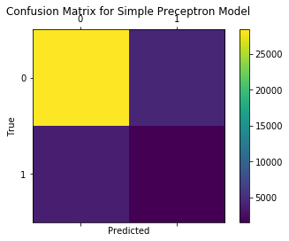

```python
labels = [0,1]
modelNameVal = 'Simple Preceptron Model'
drawConfusionMatrix(y_test, y_pred, labels,modelNameVal)
```

```python
modelName =["Model Name"]
accuracy = ["Accuracy"]
trainTime = ["Time Taken to Train"]
testTime = ["Time Taken to Predict"]
misclassified = ["Misclassified Samples"]

modelName.append(modelNameVal)
accuracy.append(round(accuracyVal,4))
trainTime.append(round(trainTimeVal,2))
testTime.append(round(testTimeVal,2))
misclassified.append(misClass)
```

After we ran the initial perceptron model, we performed feature scaling on the data to see if we can get better accuracy on the prediction. We used sklearn StandardScaler to transform the data so that the distribution will have a mean value of 0 and standard deviation of 1.

```python
# Let's standardize the continuous attributes and see
from sklearn.preprocessing import StandardScaler

sc = StandardScaler()
sc.fit(X_train)
X_train_std = sc.transform(X_train)
X_test_std = sc.transform(X_test)
```

```python
start_time = time.time()
ppn_std = Perceptron(n_iter=40, eta0=0.1, random_state=1)
ppn_std.fit(X_train_std, y_train)
end_time = time.time()
trainTimeVal = end_time - start_time
print("Time taken to train perceptron model: %.2f" % (trainTimeVal), ' seconds')
```

```
Time taken to train perceptron model: 3.38  seconds
```

```python
start_time = time.time()
y_pred = ppn_std.predict(X_test_std)
end_time = time.time()
testTimeVal = end_time - start_time
misClass = (y_test != y_pred).sum()
print('Misclassified samples: %d' % misClass )
print("Time taken to predict using perceptron model: %.2f" % (testTimeVal), ' seconds')
```

```
Misclassified samples: 7977
Time taken to predict using perceptron model: 0.02  seconds
```

```python
accuracyVal = accuracy_score(y_test, y_pred)
print('Accuracy: %.4f' % accuracyVal)
```

```
Accuracy: 0.7904
```

```
[[29294  3437]
 [ 4540   795]]
```

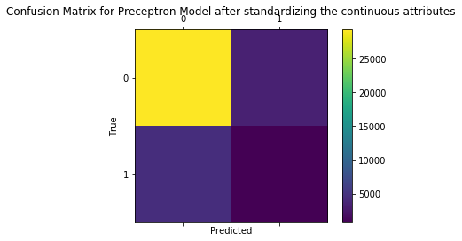

```python
modelNameVal = 'Preceptron Model after standardizing the continuous attributes'
labels = [0,1]
drawConfusionMatrix(y_test, y_pred, labels,modelNameVal)
modelName.append(modelNameVal)
accuracy.append(round(accuracyVal,4))
trainTime.append(round(trainTimeVal,2))
testTime.append(round(testTimeVal,2))
misclassified.append(misClass)
```

We noticed that the accuracy of the model increased from 0.7850 to 0.7904 after we performed feature scaling on the data. </span>

### Logistic Regression Model

This model uses the training and testing data created from the original dataset to model accident severity in UK in 2012.

```python
from sklearn.linear_model import LogisticRegression

start_time = time.time()
lr = LogisticRegression(C=100.0, random_state=1)
lr.fit(X_train_std, y_train)
end_time = time.time()
trainTimeVal = end_time - start_time
print("Time taken to train logistic regression model: %.2f" % (trainTimeVal), ' seconds')
```

```
Time taken to train logistic regression model: 30.08  seconds
```

```python
start_time = time.time()
y_pred_lr = lr.predict(X_test_std)
end_time = time.time()
testTimeVal = end_time - start_time
misclass = (y_test != y_pred_lr).sum()
print('Misclassified samples: %d' % misclass)
print("Time taken to predict using logistic regression model: %.2f" % (testTimeVal), ' seconds')
```

```
Misclassified samples: 5265
Time taken to predict using logistic regression model: 0.02  seconds
```

```python
accuracyVal = accuracy_score(y_test, y_pred_lr)
print('Accuracy: %.4f' % accuracyVal)
```

```
Accuracy: 0.8617
```

```
[[32601   130]
 [ 5135   200]]
```

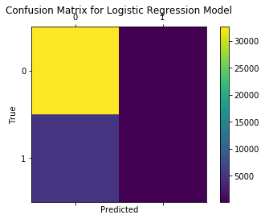

```python
modelNameVal = 'Logistic Regression Model'
labels = [0,1]
drawConfusionMatrix(y_test, y_pred_lr, labels,modelNameVal)
modelName.append(modelNameVal)
accuracy.append(round(accuracyVal,4))
trainTime.append(round(trainTimeVal,2))
testTime.append(round(testTimeVal,2))
misclassified.append(misClass)
```

### Support Vector Machine Model

This model relies upon kernel functions that work to classify observations into one or more classes. In this case, this method is used to predict accident severity based upon the model created using training data. The linear and radial basis function (RBF) kernel are explored below.

#### Linear Kernel

```python
from sklearn.svm import SVC

start_time = time.time()
svm_lin = SVC(kernel='linear', C=1.0, random_state=1, max_iter=1000)
svm_lin.fit(X_train_std, y_train)
end_time = time.time()
trainTimeVal = end_time - start_time
print("Time taken to train svm model with linear kernel: %.2f" % (trainTimeVal), ' seconds')
```

```
Time taken to train svm model with linear kernel: 70.17  seconds
```

```python
start_time = time.time()
y_pred_svm_lin = svm_lin.predict(X_test_std)
end_time = time.time()
testTimeVal = end_time - start_time
misclass = (y_test != y_pred_svm_lin).sum()
print('Misclassified samples: %d' % misclass)
print("Time taken to predict using svm model with linear kernel: %.2f" % (testTimeVal), ' seconds')
```

```
Misclassified samples: 20912
Time taken to predict using svm model with linear kernel: 14.70  seconds
```

```python
accuracyVal = accuracy_score(y_test, y_pred_svm_lin)
print('Accuracy: %.4f' % accuracyVal)
```

```
Accuracy: 0.4506
```

```
[[14445 18286]
 [ 2626  2709]]
```

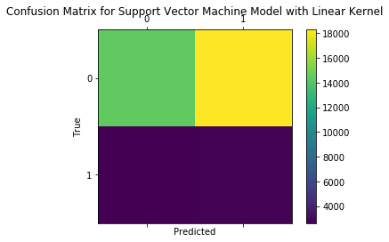

```python
modelNameVal = 'Support Vector Machine Model with Linear Kernel'
labels = [0,1]
drawConfusionMatrix(y_test, y_pred_svm_lin, labels,modelNameVal)
modelName.append(modelNameVal)
accuracy.append(round(accuracyVal,4))
trainTime.append(round(trainTimeVal,2))
testTime.append(round(testTimeVal,2))
misclassified.append(misClass)
```

#### RBF Kernel

```python
# Try other SVM kernels
start_time = time.time()
svm_rbf = SVC(kernel='rbf', random_state=1, gamma=0.10, C=1.0, max_iter=1000)
svm_rbf.fit(X_train_std, y_train)
end_time = time.time()
trainTimeVal = end_time - start_time
print("Time taken to train svm model with rbf kernel: %.2f" % (trainTimeVal), ' seconds')
```

```
Time taken to train svm model with rbf kernel: 84.52  seconds
```

```python
start_time = time.time()
y_pred_svm_rbf = svm_rbf.predict(X_test_std)
end_time = time.time()
misclass = (y_test != y_pred_svm_rbf).sum()
testTimeVal = end_time - start_time
print('Misclassified samples: %d' % misclass)
print("Time taken to predict using svm model with rbf kernel: %.2f" % (testTimeVal), ' seconds')
```

```
Misclassified samples: 5401
Time taken to predict using svm model with rbf kernel: 18.59  seconds
```

```python
accuracyVal = accuracy_score(y_test, y_pred_svm_rbf)
print('Accuracy: %.4f' % accuracyVal)
```

```
Accuracy: 0.8581
```

```
[[32641    90]
 [ 5311    24]]
```

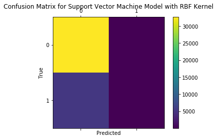

```python
modelNameVal = 'Support Vector Machine Model with RBF Kernel'
labels = [0,1]
drawConfusionMatrix(y_test, y_pred_svm_rbf, labels,modelNameVal)
modelName.append(modelNameVal)
accuracy.append(round(accuracyVal,4))
trainTime.append(round(trainTimeVal,2))
testTime.append(round(testTimeVal,2))
misclassified.append(misClass)
```

### Stochastic Gradient Descent

The stochastic gradient descent is implemented as an iterative method for optimizing the above models.

```python
from sklearn.linear_model import SGDClassifier

ppn_sgd = SGDClassifier(loss='perceptron', n_iter=1000)
lr_sgd = SGDClassifier(loss='log', n_iter=1000)
svm_sgd = SGDClassifier(loss='squared_hinge', n_iter=1000)
```

#### Perceptron with SGD

```python
start_time = time.time()
ppn_sgd.fit(X_train, y_train)
end_time = time.time()
trainTimeVal = end_time - start_time
print("Time taken to train perceptron model with SGD: %.2f" % (trainTimeVal), ' seconds')
```

```
Time taken to train perceptron model with SGD: 79.25  seconds
```

```python
start_time = time.time()
y_pred_ppn_sgd = ppn_sgd.predict(X_test_std)
end_time = time.time()
testTimeVal = end_time - start_time
misclass = (y_test != y_pred_ppn_sgd).sum()
print('Misclassified samples: %d' % misclass)
print("Time taken to predict using perceptron model with SGD: %.2f" % (testTimeVal), ' seconds')
```

```
Misclassified samples: 6393
Time taken to predict using perceptron model with SGD: 0.02  seconds
```

```python
accuracyVal = accuracy_score(y_test, y_pred_ppn_sgd)
print('Accuracy: %.4f' % accuracyVal)
```

```
Accuracy: 0.8321
```

```
[[30473  2258]
 [ 4135  1200]]
```

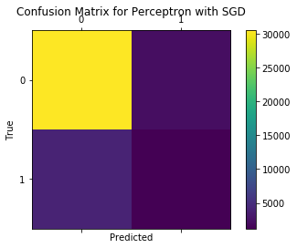

```python
modelNameVal = 'Perceptron with SGD'
labels = [0,1]
drawConfusionMatrix(y_test, y_pred_ppn_sgd, labels,modelNameVal)
modelName.append(modelNameVal)
accuracy.append(round(accuracyVal,4))
trainTime.append(round(trainTimeVal,2))
testTime.append(round(testTimeVal,2))
misclassified.append(misClass)
```

#### Logistic Regression with SGD

```python
start_time = time.time()
lr_sgd.fit(X_train, y_train)
end_time = time.time()
trainTimeVal = end_time - start_time
print("Time taken to train logistic regression model with SGD: %.2f" % (trainTimeVal), ' seconds')
```

```
Time taken to train logistic regression model with SGD: 110.01  seconds
```

```python
start_time = time.time()
y_pred_lr_sgd = lr_sgd.predict(X_test_std)
end_time = time.time()
testTimeVal = end_time - start_time
misclass = (y_test != y_pred_lr_sgd).sum()
print('Misclassified samples: %d' % misclass)
print("Time taken to predict using logistic regression model with SGD: %.2f" % (testTimeVal), ' seconds')
```

```
Misclassified samples: 5788
Time taken to predict using logistic regression model with SGD: 0.02  seconds
```

```python
accuracyVal = accuracy_score(y_test, y_pred_lr_sgd)
print('Accuracy: %.4f' % accuracyVal)
```

```
Accuracy: 0.8479
```

```
[[31455  1276]
 [ 4512   823]]
```

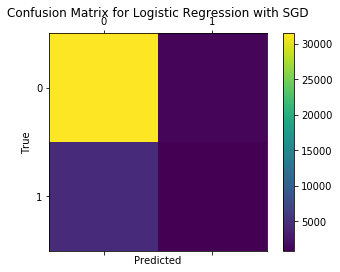

```python
modelNameVal = 'Logistic Regression with SGD'
labels = [0,1]
drawConfusionMatrix(y_test, y_pred_lr_sgd, labels,modelNameVal)
modelName.append(modelNameVal)
accuracy.append(round(accuracyVal,4))
trainTime.append(round(trainTimeVal,2))
testTime.append(round(testTimeVal,2))
misclassified.append(misClass)
```

#### SVM with quadratically penalized SGD

```python
start_time = time.time()
svm_sgd.fit(X_train, y_train)
end_time = time.time()
trainTimeVal = end_time - start_time
print("Time taken to train svm model with quadratically penalized SGD: %.2f" % (trainTimeVal), ' seconds')
```

```
Time taken to train svm model with quadratically penalized SGD: 81.28  seconds
```

```python
start_time = time.time()
y_pred_svm_sgd = svm_sgd.predict(X_test_std)
end_time = time.time()
testTimeVal = end_time - start_time
misclass = (y_test != y_pred_svm_sgd).sum()
print('Misclassified samples: %d' % misclass)
print("Time taken to predict using svm model with rbf kernel: %.2f" % (testTimeVal), ' seconds')
```

```
Misclassified samples: 5865
Time taken to predict using svm model with rbf kernel: 0.02  seconds
```

```python
accuracyVal = accuracy_score(y_test, y_pred_svm_sgd)
print('Accuracy: %.4f' % accuracyVal)
```

```
Accuracy: 0.8459
```

```
[[31334  1397]
 [ 4468   867]]
```

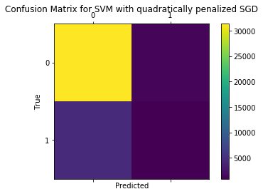

```python
modelNameVal = 'SVM with quadratically penalized SGD'
labels = [0,1]
drawConfusionMatrix(y_test, y_pred_svm_sgd, labels,modelNameVal)
modelName.append(modelNameVal)
accuracy.append(round(accuracyVal,4))
trainTime.append(round(trainTimeVal,2))
testTime.append(round(testTimeVal,2))
misclassified.append(misClass)
```

# Model Advantages

```python
import plotly.offline as py
import plotly.graph_objs as go
from plotly import __version__
from plotly.offline import download_plotlyjs, init_notebook_mode, plot, iplot
py.init_notebook_mode(connected=True)

trace = go.Table(
    header=dict(values=[modelName[0],accuracy[0],trainTime[0],testTime[0],misclassified[0]],
                line = dict(color='#7D7F80'),
                fill = dict(color='#a1c3d1'),
                align = ['left'] * 5),
    cells=dict(values=[modelName[1:],accuracy[1:],trainTime[1:],testTime[1:],misclassified[1:]],
               line = dict(color='#7D7F80'),
               fill = dict(color='#EDFAFF'),
               align = ['left'] * 5))

layout = dict(width=750, height=800)
data = [trace]
#print(data)
fig = dict(data=data, layout=layout)
py.iplot(fig, filename = 'styled_table')
```

[interactive chart not shown]

The table below has been added as the table above from the python code is not displayed unless executed.

[figure not shown]

The model with least accuracy is the SVM with linear kernel, having only 45.06% accuracy. The reason behind this is probably due to the fact that the data is not linearly seperable.

To explore the change in accuracy for a balanced dataset, the dataset was upsampled for the case where Major Accident = 1. The existing dataset has the below number of instances for case 0 & 1. Also, the case for Major Accident = 0 was down sampled to match the number of instances where Major Accident = 1.

```python
print('Major Accidents count split: ', df['Major Accident'].value_counts())
```

```
Major Accidents count split:  0    163657
1     26673
Name: Major Accident, dtype: int64
```

#### Upsample minority class / Down sample majority class

```python
from sklearn.utils import resample
#### Upsampling
df_majority = df[df['Major Accident']==0]
df_minority = df[df['Major Accident']==1]


df_minority_upsampled = resample(df_minority,
                                 replace=True,     # sample with replacement
                                 n_samples=163657,    # to match majority class
                                 random_state=123) # reproducible results

# Combine majority class with upsampled minority class
df_upsampled = pd.concat([df_majority, df_minority_upsampled])

#df = df_upsampled
# Display new class counts
df_upsampled['Major Accident'].value_counts()
```

```
1    163657
0    163657
Name: Major Accident, dtype: int64
```

```python
# Downsample majority class
df_majority_downsampled = resample(df_majority,
                                 replace=False,    # sample without replacement
                                 n_samples=26673,     # to match minority class
                                 random_state=123) # reproducible results

# Combine minority class with downsampled majority class
df_downsampled = pd.concat([df_majority_downsampled, df_minority])
# Display new class counts
df_downsampled['Major Accident'].value_counts()
```

```
1    26673
0    26673
Name: Major Accident, dtype: int64
```

The table below shows the previous image altered for Accuracy and time taken for the models after up sampling / down sampling.

[figure not shown]

The accuracy did not improve any further and seems to be quite less than the results from the models ran on the original dataset. In the real world, the data will never be balanced and the drop in accuracy for the manipulated balanced dataset reflects this.

# Interpret Feature Importance

```python
weights = lr.coef_.T
variable_names = df.columns
for coef, name in zip(weights, variable_names):
    print(name, 'has weight of', coef[0])
```

```
Longitude has weight of -0.02426457205916668
Latitude has weight of 0.07382929241507488
Number of Vehicles has weight of -0.07178516897251777
Number of Casualties has weight of 0.2538873049956758
Road Type has weight of 0.13330004149999944
Speed limit has weight of 0.05025803141080961
Junction Detail has weight of 0.01567721775277332
Junction Control has weight of 0.005899521445652666
Light Conditions has weight of -0.003484668710067623
Weather Conditions has weight of 0.02197907542028548
Road Surface Conditions has weight of -0.027357549055288456
Urban or Rural Area has weight of 0.03047919804024278
Vehicle Type has weight of 0.0
Vehicle Manoeuvre has weight of -0.0573005374373912
Junction Location has weight of 0.008858137570477922
Skidding and Overturning has weight of -0.01880571105690346
Hit Object in Carriageway has weight of 0.06615885750053041
Vehicle Leaving Carriageway has weight of -0.030486239917620145
Hit Object off Carriageway has weight of -0.016298242666100346
1st Point of Impact has weight of 0.0976252603840318
Was Vehicle Left Hand Drive? has weight of 0.012212118723353035
Journey Purpose of Driver has weight of 0.04553883782350727
Sex of Driver has weight of -0.30829775644503266
Age Band of Driver has weight of 0.04698935310517053
Engine Capacity (CC) has weight of 0.07461284260681647
Propulsion Code has weight of -0.029038026197161997
Age of Vehicle has weight of 0.03358743506025729
Driver IMD Decile has weight of 0.20462780326968458
Driver Home Area Type has weight of 0.0014858408238081489
Date.month has weight of 0.10528442388920796
Date.day-of-month has weight of -0.2680517045809938
Date.day-of-week has weight of 0.1903278714691179
Date.hour has weight of 0.02363447621169557
Date.minute has weight of -0.013087155831818197
Date.second has weight of 0.05659613960140892
Major Accident has weight of -0.016449547616765783
```

```python
from sklearn.preprocessing import StandardScaler
from sklearn import metrics as mt

scl_obj = StandardScaler()
scl_obj.fit(X_train)

X_train_scaled = scl_obj.transform(X_train)
X_test_scaled = scl_obj.transform(X_test)

lr_clf = LogisticRegression(penalty='l2', C=0.05)
lr_clf.fit(X_train_scaled,y_train)

y_hat = lr_clf.predict(X_test_scaled)

acc = mt.accuracy_score(y_test,y_hat)
conf = mt.confusion_matrix(y_test,y_hat)
print('accuracy:', acc )
print(conf )

# sort attributes
zip_vars = zip(lr.coef_.T,df.columns)
zip_vars = sorted(zip_vars)
for coef, name in zip_vars:
    print(name, 'has weight of', coef[0])
```

```
accuracy: 0.8616875952293385
[[32602   129]
 [ 5136   199]]
Sex of Driver has weight of -0.30829775644503266
Date.day-of-month has weight of -0.2680517045809938
Number of Vehicles has weight of -0.07178516897251777
Vehicle Manoeuvre has weight of -0.0573005374373912
Vehicle Leaving Carriageway has weight of -0.030486239917620145
Propulsion Code has weight of -0.029038026197161997
Road Surface Conditions has weight of -0.027357549055288456
Longitude has weight of -0.02426457205916668
Skidding and Overturning has weight of -0.01880571105690346
Major Accident has weight of -0.016449547616765783
Hit Object off Carriageway has weight of -0.016298242666100346
Date.minute has weight of -0.013087155831818197
Light Conditions has weight of -0.003484668710067623
Vehicle Type has weight of 0.0
Driver Home Area Type has weight of 0.0014858408238081489
Junction Control has weight of 0.005899521445652666
Junction Location has weight of 0.008858137570477922
Was Vehicle Left Hand Drive? has weight of 0.012212118723353035
Junction Detail has weight of 0.01567721775277332
Weather Conditions has weight of 0.02197907542028548
Date.hour has weight of 0.02363447621169557
Urban or Rural Area has weight of 0.03047919804024278
Age of Vehicle has weight of 0.03358743506025729
Journey Purpose of Driver has weight of 0.04553883782350727
Age Band of Driver has weight of 0.04698935310517053
Speed limit has weight of 0.05025803141080961
Date.second has weight of 0.05659613960140892
Hit Object in Carriageway has weight of 0.06615885750053041
Latitude has weight of 0.07382929241507488
Engine Capacity (CC) has weight of 0.07461284260681647
1st Point of Impact has weight of 0.0976252603840318
Date.month has weight of 0.10528442388920796
Road Type has weight of 0.13330004149999944
Date.day-of-week has weight of 0.1903278714691179
Driver IMD Decile has weight of 0.20462780326968458
Number of Casualties has weight of 0.2538873049956758
```

#### Visualizations

As per the graph below, the importance of each variable, whether positive or negative, are compared against each other. From analysis, the following conclusions may be drawn in order to reduce the dimensionality of the dataset:

Some other attributes that have a significant contribution to the model, based on the logistic regression coefficient plot below are number of casualties and vehicle type.

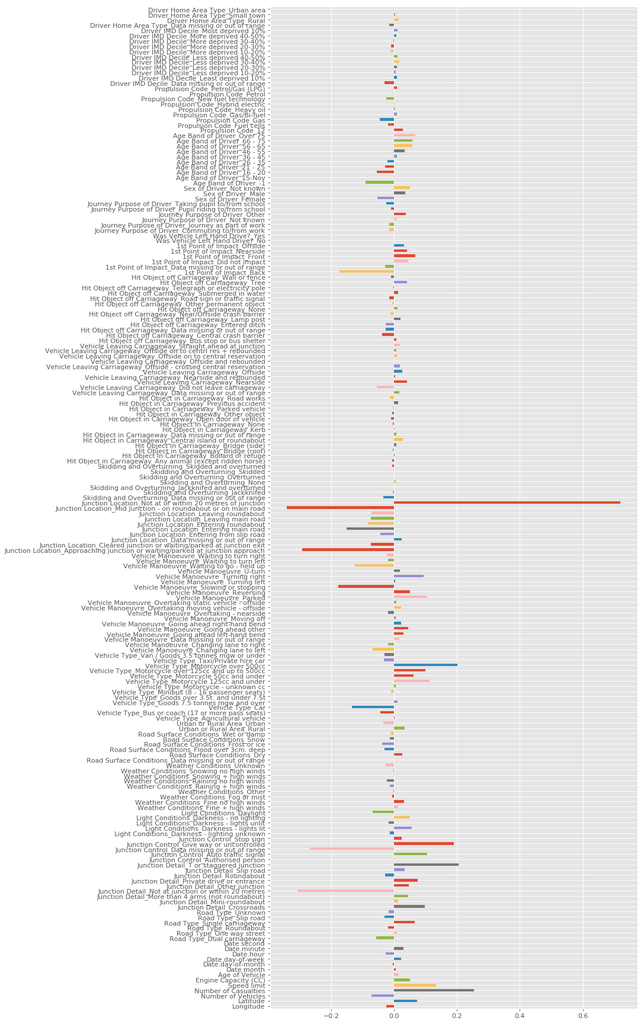

```python
from matplotlib import pyplot as plt
%matplotlib inline
plt.style.use('ggplot')
plt.figure(figsize=(10, 28), dpi=80)

lgreg_coef = lr.coef_
weights = pd.Series(lgreg_coef[0],index=X.columns)
weights.plot(kind='barh')
plt.show()
```

```python
from sklearn.feature_extraction.text import CountVectorizer
from sklearn.svm import LinearSVC
import matplotlib.pyplot as plt

# Code from https://medium.com/@aneesha/visualising-top-features-in-linear-svm-with-scikit-learn-and-matplotlib-3454ab18a14d
def plot_coefficients(classifier, feature_names, top_features=10):
    coef = classifier.coef_.ravel()
    top_positive_coefficients = np.argsort(coef)[-top_features:]
    top_negative_coefficients = np.argsort(coef)[:top_features]
    top_coefficients = np.hstack([top_negative_coefficients, top_positive_coefficients])
    # create plot
    plt.figure(figsize=(15, 5))
    colors = ['red' if c < 0 else 'blue' for c in coef[top_coefficients]]
    plt.bar(np.arange(2 * top_features), coef[top_coefficients], color=colors)
    feature_names = np.array(feature_names)
    plt.xticks(np.arange(1, 1 + 2 * top_features), feature_names[top_coefficients], rotation=60, ha='right')
    plt.show()
```

The visualizations below are based on the weights of the coefficients of the respective models.

#### Perceptron

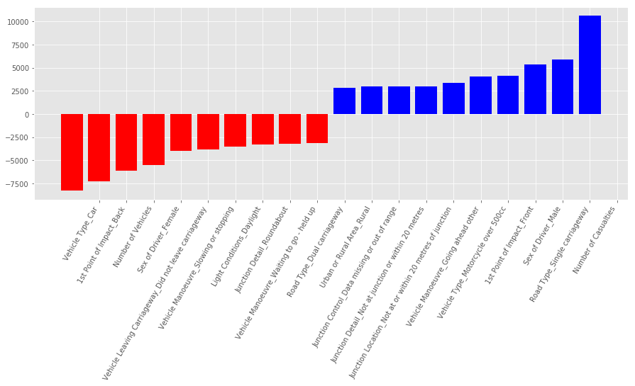

```python
cv = CountVectorizer()
cv.fit(X)

plot_coefficients(ppn, X.columns)
```

#### Perceptron with feature scaling

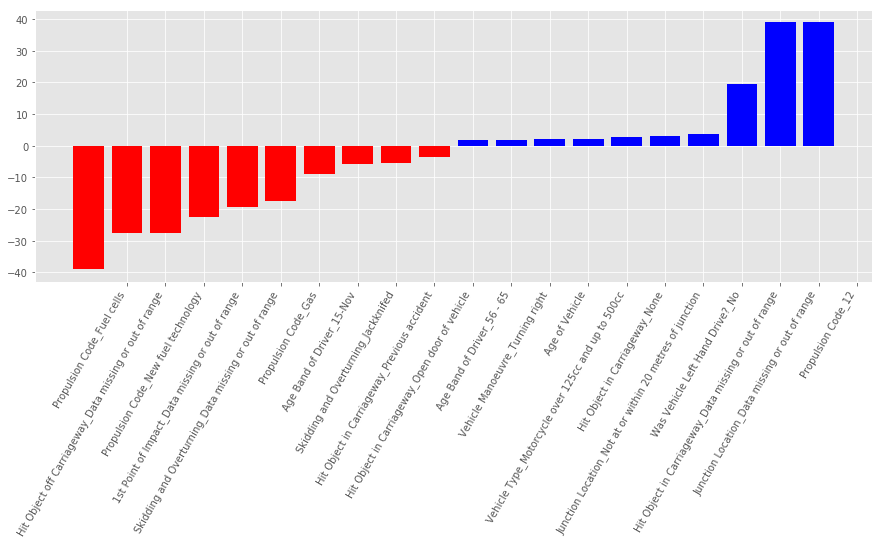

```python
plot_coefficients(ppn_std, X.columns)
```

#### Logistic Regression

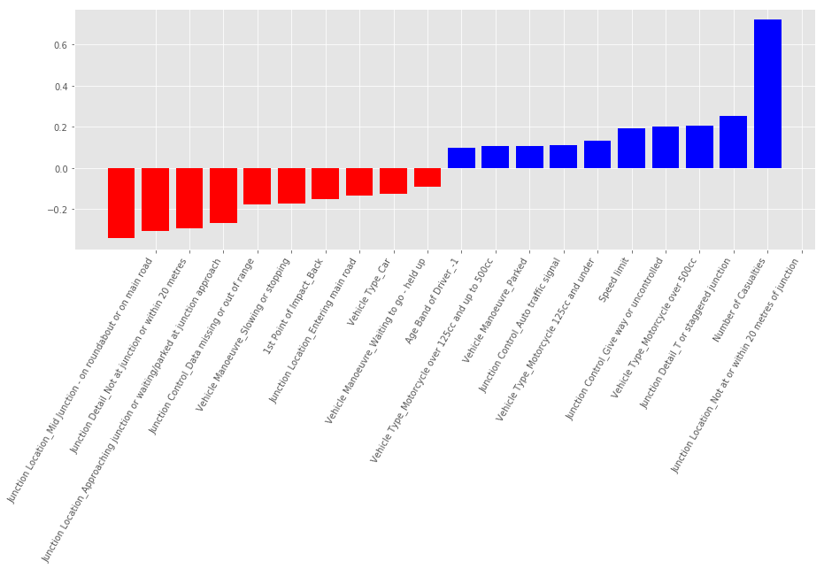

```python
plot_coefficients(lr, X.columns)
```

#### SVM with Linear Kernel

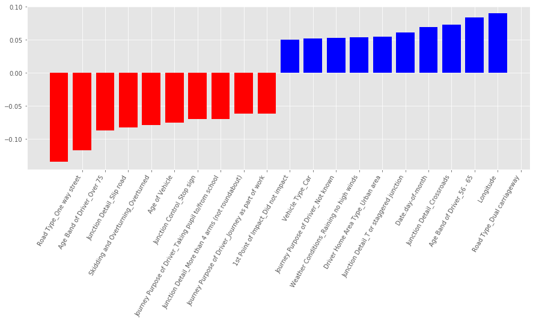

```python
plot_coefficients(svm_lin, X.columns)
```

#### Perceptron with SGD

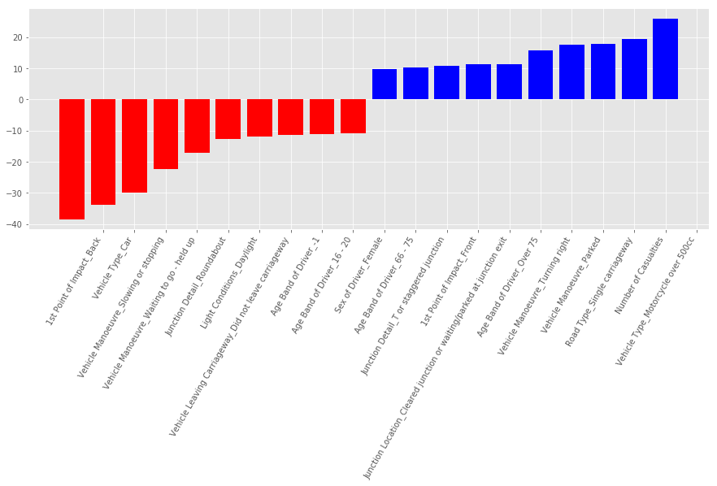

```python
plot_coefficients(ppn_sgd, X.columns)
```

# Interpret Support Vectors

Based on our analysis, a linear svm does not appear to be an appropriate solution for this dataset and is too idealistic. This means that we cannot reasonably draw a dividing line with a linear svm given the overlap in our data in multidimensional space.

```python
support_vectors_rbf = pd.DataFrame(svm_rbf.support_vectors_, columns=X.columns)
support_vectors_lin = pd.DataFrame(svm_lin.support_vectors_, columns=X.columns)

# get number of support vectors for each class
print('Number of support vectors (svm with rbf kernel):', svm_rbf.n_support_)
print('Number of support vectors (svm with linear kernel):', svm_lin.n_support_)
```

```
Number of support vectors (svm with rbf kernel): [1000 1000]
Number of support vectors (svm with linear kernel): [874 924]
```

```python
from sklearn import metrics

print("Precision:", metrics.precision_score(y_test, y_pred_svm_sgd))
print("Recall:", metrics.recall_score(y_test, y_pred_svm_sgd))
```

```
Precision: 0.3829505300353357
Recall: 0.16251171508903467
```

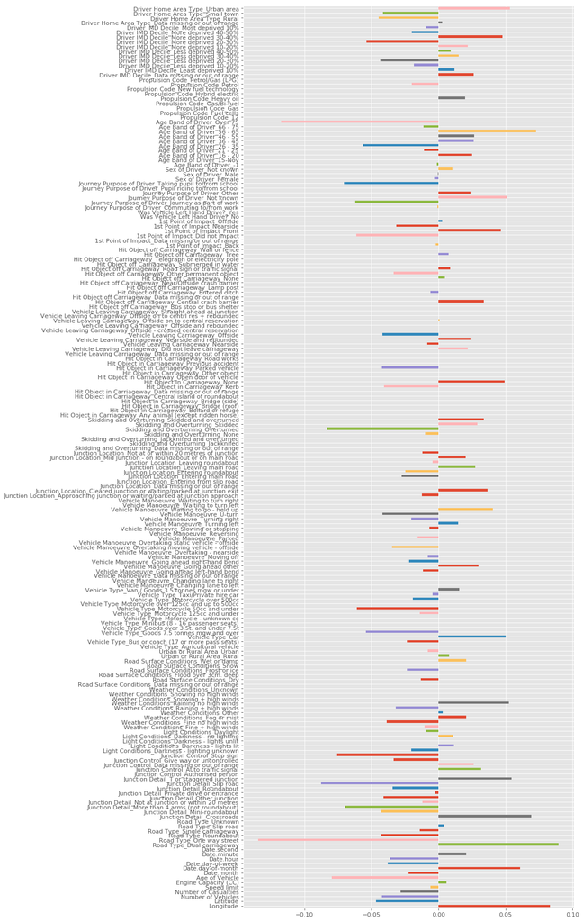

```python
#plots linear svm coefficients
from matplotlib import pyplot as plt
%matplotlib inline
plt.style.use('ggplot')
plt.figure(figsize=(10, 28), dpi=80)

weights = pd.Series(svm_lin.coef_[0],index=X.columns)
weights.plot(kind='barh')
plt.show()
```

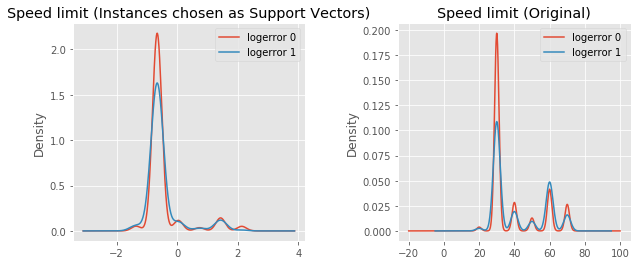

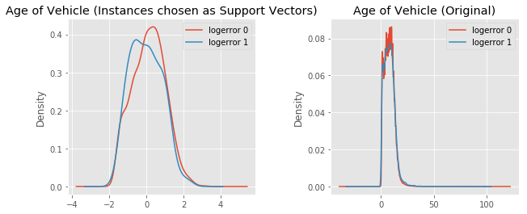

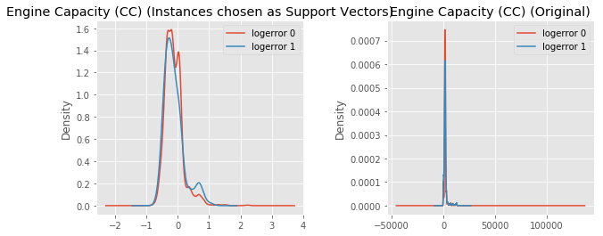

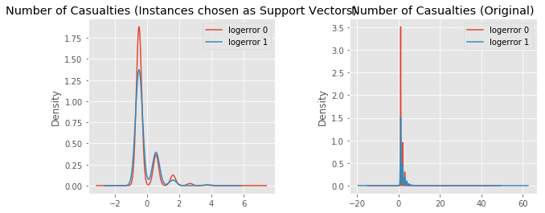

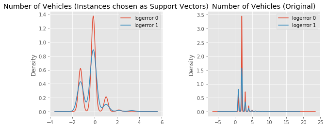

```python
features_to_plot = ['Speed limit','Age of Vehicle','Engine Capacity (CC)', 'Number of Casualties', 'Number of Vehicles']

grouped_vectors = support_vectors_rbf.groupby(y.loc[svm_rbf.support_].values)
grouped_X = X.groupby(y.values)

for f in features_to_plot:
    plt.figure(figsize=(10,4)).subplots_adjust(wspace=.4)

    plt.subplot(1,2,1)
    grouped_vectors[f].plot.kde()
    plt.legend(['logerror 0','logerror 1'])
    plt.title(f+' (Instances chosen as Support Vectors)')

    plt.subplot(1,2,2)
    grouped_X[f].plot.kde()
    plt.legend(['logerror 0','logerror 1'])
    plt.title(f+' (Original)')
```

The graphs above show the original statistics of the data (right) versus the statistics of the support vectors (left). The separation in the original data is greater compared to those of the support vectors.

The densities differ between the original and support vectors based on the variable. For speed limit, age of vehicle, and engine capacity, the densities of the support vectors are significantly larger than those of the original statistics. For number of casualties and number of vehicle, the densities of the original statistics are higher than those of the support vectors.

## References

[1] https://stackoverflow.com/questions/41592661/determining-the-most-contributing-features-for-svm-classifier-in-sklearn

[2] https://medium.com/@aneesha/visualising-top-features-in-linear-svm-with-scikit-learn-and-matplotlib-3454ab18a14d